# INN Hotels Project

## Context

A significant number of hotel bookings are called-off due to cancellations or no-shows. The typical reasons for cancellations include change of plans, scheduling conflicts, etc. This is often made easier by the option to do so free of charge or preferably at a low cost which is beneficial to hotel guests but it is a less desirable and possibly revenue-diminishing factor for hotels to deal with. Such losses are particularly high on last-minute cancellations.

The new technologies involving online booking channels have dramatically changed customers’ booking possibilities and behavior. This adds a further dimension to the challenge of how hotels handle cancellations, which are no longer limited to traditional booking and guest characteristics.

The cancellation of bookings impact a hotel on various fronts:

- Loss of resources (revenue) when the hotel cannot resell the room.
- Additional costs of distribution channels by increasing commissions or paying for publicity to help sell these rooms.
- Lowering prices last minute, so the hotel can resell a room, resulting in reducing the profit margin.
- Human resources to make arrangements for the guests.

## Objective

The increasing number of cancellations calls for a Machine Learning based solution that can help in predicting which booking is likely to be canceled. INN Hotels Group has a chain of hotels in Portugal, they are facing problems with the high number of booking cancellations and have reached out to your firm for data-driven solutions. You as a data scientist have to analyze the data provided to find which factors have a high influence on booking cancellations, build a predictive model that can predict which booking is going to be canceled in advance, and help in formulating profitable policies for cancellations and refunds.

## Data Description

The data contains the different attributes of customers' booking details. The detailed data dictionary is given below.

**Data Dictionary**

- Booking_ID: unique identifier of each booking
- no_of_adults: Number of adults
- no_of_children: Number of Children
- no_of_weekend_nights: Number of weekend nights (Saturday or Sunday) the guest stayed or booked to stay at the hotel
- no_of_week_nights: Number of week nights (Monday to Friday) the guest stayed or booked to stay at the hotel
- type_of_meal_plan: Type of meal plan booked by the customer:
  - Not Selected – No meal plan selected
  - Meal Plan 1 – Breakfast
  - Meal Plan 2 – Half board (breakfast and one other meal)
  - Meal Plan 3 – Full board (breakfast, lunch, and dinner)
- required_car_parking_space: Does the customer require a car parking space? (0 - No, 1- Yes)
- room_type_reserved: Type of room reserved by the customer. The values are ciphered (encoded) by INN Hotels.
- lead_time: Number of days between the date of booking and the arrival date
- arrival_year: Year of arrival date
- arrival_month: Month of arrival date
- arrival_date: Date of the month
- market_segment_type: Market segment designation.
- repeated_guest: Is the customer a repeated guest? (0 - No, 1- Yes)
- no_of_previous_cancellations: Number of previous bookings that were canceled by the customer prior to the current booking
- no_of_previous_bookings_not_canceled: Number of previous bookings not canceled by the customer prior to the current booking
- avg_price_per_room: Average price per day of the reservation; prices of the rooms are dynamic. (in euros)
- no_of_special_requests: Total number of special requests made by the customer (e.g. high floor, view from the room, etc)
- booking_status: Flag indicating if the booking was canceled or not.

## Importing necessary libraries and data

```python
# Installing the libraries with the specified version.
!pip install pandas==1.5.3 numpy==1.25.2 matplotlib==3.7.1 seaborn==0.13.1 scikit-learn==1.2.2 statsmodels==0.14.1 -q --user
```

[output not shown]

**Note**: *After running the above cell, kindly restart the notebook kernel and run all cells sequentially from the start again.*

```python
from google.colab import drive
drive.mount('/content/drive')
```

```python
import pandas as pd
import numpy as np
import matplotlib.pyplot as plt
import seaborn as sns

# To ignore warnings
import warnings
warnings.filterwarnings('ignore')

# Remove the limit from the number of displayed columns and rows.
pd.set_option("display.max_columns", None)
pd.set_option("display.max_rows", None)

df = pd.read_csv("/content/drive/MyDrive/INN_hotel_data/INNHotelsGroup.csv")
```

## Data Overview

- Observations
- Sanity checks

```python
df.head()
```

|  | Booking_ID | no_of_adults | no_of_children | no_of_weekend_nights | no_of_week_nights | type_of_meal_plan | required_car_parking_space | room_type_reserved | lead_time | arrival_year | arrival_month | arrival_date | market_segment_type | repeated_guest | no_of_previous_cancellations | no_of_previous_bookings_not_canceled | avg_price_per_room | no_of_special_requests | booking_status |
| --- | --- | --- | --- | --- | --- | --- | --- | --- | --- | --- | --- | --- | --- | --- | --- | --- | --- | --- | --- |
| 0 | INN00001 | 2 | 0 | 1 | 2 | Meal Plan 1 | 0 | Room_Type 1 | 224 | 2017 | 10 | 2 | Offline | 0 | 0 | 0 | 65.00 | 0 | Not_Canceled |
| 1 | INN00002 | 2 | 0 | 2 | 3 | Not Selected | 0 | Room_Type 1 | 5 | 2018 | 11 | 6 | Online | 0 | 0 | 0 | 106.68 | 1 | Not_Canceled |
| 2 | INN00003 | 1 | 0 | 2 | 1 | Meal Plan 1 | 0 | Room_Type 1 | 1 | 2018 | 2 | 28 | Online | 0 | 0 | 0 | 60.00 | 0 | Canceled |
| 3 | INN00004 | 2 | 0 | 0 | 2 | Meal Plan 1 | 0 | Room_Type 1 | 211 | 2018 | 5 | 20 | Online | 0 | 0 | 0 | 100.00 | 0 | Canceled |
| 4 | INN00005 | 2 | 0 | 1 | 1 | Not Selected | 0 | Room_Type 1 | 48 | 2018 | 4 | 11 | Online | 0 | 0 | 0 | 94.50 | 0 | Canceled |

```python
#checking data types
df.info()
```

```
<class 'pandas.core.frame.DataFrame'>
RangeIndex: 36275 entries, 0 to 36274
Data columns (total 19 columns):
 #   Column                                Non-Null Count  Dtype
---  ------                                --------------  -----
 0   Booking_ID                            36275 non-null  object
 1   no_of_adults                          36275 non-null  int64
 2   no_of_children                        36275 non-null  int64
 3   no_of_weekend_nights                  36275 non-null  int64
 4   no_of_week_nights                     36275 non-null  int64
 5   type_of_meal_plan                     36275 non-null  object
 6   required_car_parking_space            36275 non-null  int64
 7   room_type_reserved                    36275 non-null  object
 8   lead_time                             36275 non-null  int64
 9   arrival_year                          36275 non-null  int64
 10  arrival_month                         36275 non-null  int64
 11  arrival_date                          36275 non-null  int64
 12  market_segment_type                   36275 non-null  object
 13  repeated_guest                        36275 non-null  int64
 14  no_of_previous_cancellations          36275 non-null  int64
 15  no_of_previous_bookings_not_canceled  36275 non-null  int64
 16  avg_price_per_room                    36275 non-null  float64
 17  no_of_special_requests                36275 non-null  int64
 18  booking_status                        36275 non-null  object
dtypes: float64(1), int64(13), object(5)
memory usage: 5.3+ MB
```

```python
#checking min and max values for price fields
df.describe().T
```

|  | count | mean | std | min | 25% | 50% | 75% | max |
| --- | --- | --- | --- | --- | --- | --- | --- | --- |
| no_of_adults | 36275.0 | 1.844962 | 0.518715 | 0.0 | 2.0 | 2.00 | 2.0 | 4.0 |
| no_of_children | 36275.0 | 0.105279 | 0.402648 | 0.0 | 0.0 | 0.00 | 0.0 | 10.0 |
| no_of_weekend_nights | 36275.0 | 0.810724 | 0.870644 | 0.0 | 0.0 | 1.00 | 2.0 | 7.0 |
| no_of_week_nights | 36275.0 | 2.204300 | 1.410905 | 0.0 | 1.0 | 2.00 | 3.0 | 17.0 |
| required_car_parking_space | 36275.0 | 0.030986 | 0.173281 | 0.0 | 0.0 | 0.00 | 0.0 | 1.0 |
| lead_time | 36275.0 | 85.232557 | 85.930817 | 0.0 | 17.0 | 57.00 | 126.0 | 443.0 |
| arrival_year | 36275.0 | 2017.820427 | 0.383836 | 2017.0 | 2018.0 | 2018.00 | 2018.0 | 2018.0 |
| arrival_month | 36275.0 | 7.423653 | 3.069894 | 1.0 | 5.0 | 8.00 | 10.0 | 12.0 |
| arrival_date | 36275.0 | 15.596995 | 8.740447 | 1.0 | 8.0 | 16.00 | 23.0 | 31.0 |
| repeated_guest | 36275.0 | 0.025637 | 0.158053 | 0.0 | 0.0 | 0.00 | 0.0 | 1.0 |
| no_of_previous_cancellations | 36275.0 | 0.023349 | 0.368331 | 0.0 | 0.0 | 0.00 | 0.0 | 13.0 |
| no_of_previous_bookings_not_canceled | 36275.0 | 0.153411 | 1.754171 | 0.0 | 0.0 | 0.00 | 0.0 | 58.0 |
| avg_price_per_room | 36275.0 | 103.423539 | 35.089424 | 0.0 | 80.3 | 99.45 | 120.0 | 540.0 |
| no_of_special_requests | 36275.0 | 0.619655 | 0.786236 | 0.0 | 0.0 | 0.00 | 1.0 | 5.0 |

```python
#checking for nulls
df.isnull().sum()
```

|  | 0 |
| --- | --- |
| Booking_ID | 0 |
| no_of_adults | 0 |
| no_of_children | 0 |
| no_of_weekend_nights | 0 |
| no_of_week_nights | 0 |
| type_of_meal_plan | 0 |
| required_car_parking_space | 0 |
| room_type_reserved | 0 |
| lead_time | 0 |
| arrival_year | 0 |
| arrival_month | 0 |
| arrival_date | 0 |
| market_segment_type | 0 |
| repeated_guest | 0 |
| no_of_previous_cancellations | 0 |
| no_of_previous_bookings_not_canceled | 0 |
| avg_price_per_room | 0 |
| no_of_special_requests | 0 |
| booking_status | 0 |

**dtype:** int64

## Exploratory Data Analysis (EDA)

- EDA is an important part of any project involving data.
- It is important to investigate and understand the data better before building a model with it.
- A few questions have been mentioned below which will help you approach the analysis in the right manner and generate insights from the data.
- A thorough analysis of the data, in addition to the questions mentioned below, should be done.

**Leading Questions**:

1. What are the busiest months in the hotel?
2. Which market segment do most of the guests come from?
3. Hotel rates are dynamic and change according to demand and customer demographics. What are the differences in room prices in different market segments?
4. What percentage of bookings are canceled?
5. Repeating guests are the guests who stay in the hotel often and are important to brand equity. What percentage of repeating guests cancel?
6. Many guests have special requirements when booking a hotel room. Do these requirements affect booking cancellation?

```python
#Top three busiest months
df['arrival_month'].value_counts().head(3)
```

| arrival_month | count |
| --- | --- |
| 10 | 5317 |
| 9 | 4611 |
| 8 | 3813 |

**dtype:** int64

```python
#Highest Customer Market Segment
df['market_segment_type'].value_counts()
```

| market_segment_type | count |
| --- | --- |
| Online | 23214 |
| Offline | 10528 |
| Corporate | 2017 |
| Complementary | 391 |
| Aviation | 125 |

**dtype:** int64

```python
#Differences of room prices based on market segmentation
df.groupby('market_segment_type')['avg_price_per_room'].mean()
```

| market_segment_type | avg_price_per_room |
| --- | --- |
| Aviation | 100.704000 |
| Complementary | 3.141765 |
| Corporate | 82.911740 |
| Offline | 91.632679 |
| Online | 112.256855 |

**dtype:** float64

```python
#Percentage of Cancelations
df['booking_status'].value_counts(normalize=True)
```

| booking_status | proportion |
| --- | --- |
| Not_Canceled | 0.672364 |
| Canceled | 0.327636 |

**dtype:** float64

```python
#Percentage of Repeating Guest that cancel
df[df['repeated_guest']==1]['booking_status'].value_counts(normalize=True)
```

| booking_status | proportion |
| --- | --- |
| Not_Canceled | 0.982796 |
| Canceled | 0.017204 |

**dtype:** float64

```python
#Percentage of Special requirement Guest that cancel
df[df['no_of_special_requests']>0]['booking_status'].value_counts(normalize=True)
```

| booking_status | proportion |
| --- | --- |
| Not_Canceled | 0.797551 |
| Canceled | 0.202449 |

**dtype:** float64

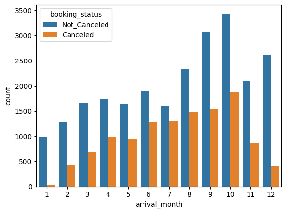

```python
#Book status cancelation by month bar plot
sns.countplot(x='arrival_month', hue='booking_status', data=df)
```

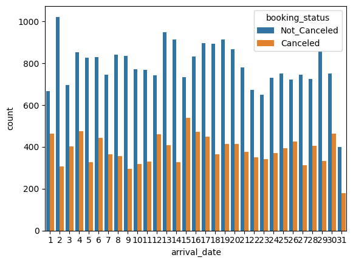

```python
#Booking status by day of the month
sns.countplot(x='arrival_date', hue='booking_status', data=df)
```

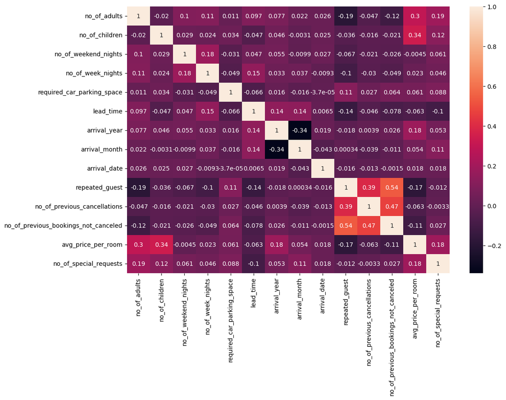

```python
#correlation heatmap
# Select only numerical columns
numerical_df = df.select_dtypes(include=['int64', 'float64'])

# Compute correlation matrix
corr_matrix = numerical_df.corr()

# Plot heatmap
fig, ax = plt.subplots(figsize=(12, 8))  # Adjust width and height as needed
sns.heatmap(corr_matrix, annot=True, ax=ax)
plt.show()
```

## Data Preprocessing

- Missing value treatment (if needed)
- Feature engineering (if needed)
- Outlier detection and treatment (if needed)
- Preparing data for modeling
- Any other preprocessing steps (if needed)

```python
#Engineering new feature total guests
df['total_guests'] = df['no_of_adults'] + df['no_of_children']
```

```python
#New Feature: Customer History Score
df['customer_history_score'] = df['no_of_previous_bookings_not_canceled'] - df['no_of_previous_cancellations']
```

```python
#One-hot-encoding: Market Segmentation
df = pd.get_dummies(df, columns=['market_segment_type'], prefix='market_segment', drop_first=True)
```

```python
#One-hot-encoding: Meal Type
df = pd.get_dummies(df, columns=['type_of_meal_plan'], prefix='meal',drop_first=True)
```

```python
#One-hot-encoding: Booking Status
df = pd.get_dummies(df, columns=['booking_status'], prefix='status',drop_first=True)
```

```python
#One-hot-encoding: Room Type
df = pd.get_dummies(df, columns=['room_type_reserved'], prefix='room',drop_first=True)
```

## EDA

- It is a good idea to explore the data once again after manipulating it.

```python
df.head()
```

|  | Booking_ID | no_of_adults | no_of_children | no_of_weekend_nights | no_of_week_nights | required_car_parking_space | lead_time | arrival_year | arrival_month | arrival_date | repeated_guest | no_of_previous_cancellations | no_of_previous_bookings_not_canceled | avg_price_per_room | no_of_special_requests | total_guests | customer_history_score | market_segment_Complementary | market_segment_Corporate | market_segment_Offline | market_segment_Online | meal_Meal Plan 2 | meal_Meal Plan 3 | meal_Not Selected | status_Not_Canceled | room_Room_Type 2 | room_Room_Type 3 | room_Room_Type 4 | room_Room_Type 5 | … |
| --- | --- | --- | --- | --- | --- | --- | --- | --- | --- | --- | --- | --- | --- | --- | --- | --- | --- | --- | --- | --- | --- | --- | --- | --- | --- | --- | --- | --- | --- | --- |
| 0 | INN00001 | 2 | 0 | 1 | 2 | 0 | 224 | 2017 | 10 | 2 | 0 | 0 | 0 | 65.00 | 0 | 2 | 0 | False | False | True | False | False | False | False | True | False | False | False | False | … |
| 1 | INN00002 | 2 | 0 | 2 | 3 | 0 | 5 | 2018 | 11 | 6 | 0 | 0 | 0 | 106.68 | 1 | 2 | 0 | False | False | False | True | False | False | True | True | False | False | False | False | … |
| 2 | INN00003 | 1 | 0 | 2 | 1 | 0 | 1 | 2018 | 2 | 28 | 0 | 0 | 0 | 60.00 | 0 | 1 | 0 | False | False | False | True | False | False | False | False | False | False | False | False | … |
| 3 | INN00004 | 2 | 0 | 0 | 2 | 0 | 211 | 2018 | 5 | 20 | 0 | 0 | 0 | 100.00 | 0 | 2 | 0 | False | False | False | True | False | False | False | False | False | False | False | False | … |
| 4 | INN00005 | 2 | 0 | 1 | 1 | 0 | 48 | 2018 | 4 | 11 | 0 | 0 | 0 | 94.50 | 0 | 2 | 0 | False | False | False | True | False | False | True | False | False | False | False | False | … |

```python
df.isnull().sum()
```

|  | 0 |
| --- | --- |
| Booking_ID | 0 |
| no_of_adults | 0 |
| no_of_children | 0 |
| no_of_weekend_nights | 0 |
| no_of_week_nights | 0 |
| required_car_parking_space | 0 |
| lead_time | 0 |
| arrival_year | 0 |
| arrival_month | 0 |
| arrival_date | 0 |
| repeated_guest | 0 |
| no_of_previous_cancellations | 0 |
| no_of_previous_bookings_not_canceled | 0 |
| avg_price_per_room | 0 |
| no_of_special_requests | 0 |
| total_guests | 0 |
| customer_history_score | 0 |
| market_segment_Complementary | 0 |
| market_segment_Corporate | 0 |
| market_segment_Offline | 0 |
| market_segment_Online | 0 |
| meal_Meal Plan 2 | 0 |
| meal_Meal Plan 3 | 0 |
| meal_Not Selected | 0 |
| status_Not_Canceled | 0 |
| room_Room_Type 2 | 0 |
| room_Room_Type 3 | 0 |
| room_Room_Type 4 | 0 |
| room_Room_Type 5 | 0 |
| room_Room_Type 6 | 0 |
| room_Room_Type 7 | 0 |

**dtype:** int64

```python
#Dropping Booking ID before modeling
df.drop('Booking_ID', axis=1, inplace=True)
```

```python
df.head()
```

|  | no_of_adults | no_of_children | no_of_weekend_nights | no_of_week_nights | required_car_parking_space | lead_time | arrival_year | arrival_month | arrival_date | repeated_guest | no_of_previous_cancellations | no_of_previous_bookings_not_canceled | avg_price_per_room | no_of_special_requests | total_guests | customer_history_score | market_segment_Complementary | market_segment_Corporate | market_segment_Offline | market_segment_Online | meal_Meal Plan 2 | meal_Meal Plan 3 | meal_Not Selected | status_Not_Canceled | room_Room_Type 2 | room_Room_Type 3 | room_Room_Type 4 | room_Room_Type 5 | room_Room_Type 6 | … |
| --- | --- | --- | --- | --- | --- | --- | --- | --- | --- | --- | --- | --- | --- | --- | --- | --- | --- | --- | --- | --- | --- | --- | --- | --- | --- | --- | --- | --- | --- | --- |
| 0 | 2 | 0 | 1 | 2 | 0 | 224 | 2017 | 10 | 2 | 0 | 0 | 0 | 65.00 | 0 | 2 | 0 | False | False | True | False | False | False | False | True | False | False | False | False | False | … |
| 1 | 2 | 0 | 2 | 3 | 0 | 5 | 2018 | 11 | 6 | 0 | 0 | 0 | 106.68 | 1 | 2 | 0 | False | False | False | True | False | False | True | True | False | False | False | False | False | … |
| 2 | 1 | 0 | 2 | 1 | 0 | 1 | 2018 | 2 | 28 | 0 | 0 | 0 | 60.00 | 0 | 1 | 0 | False | False | False | True | False | False | False | False | False | False | False | False | False | … |
| 3 | 2 | 0 | 0 | 2 | 0 | 211 | 2018 | 5 | 20 | 0 | 0 | 0 | 100.00 | 0 | 2 | 0 | False | False | False | True | False | False | False | False | False | False | False | False | False | … |
| 4 | 2 | 0 | 1 | 1 | 0 | 48 | 2018 | 4 | 11 | 0 | 0 | 0 | 94.50 | 0 | 2 | 0 | False | False | False | True | False | False | True | False | False | False | False | False | False | … |

## Checking Multicollinearity

- In order to make statistical inferences from a logistic regression model, it is important to ensure that there is no multicollinearity present in the data.

```python
from statsmodels.stats.outliers_influence import variance_inflation_factor
import pandas as pd

X=df.copy()

# Convert boolean columns to integers (0 or 1)
for col in X.columns:
    if X[col].dtype == 'bool':
        X[col] = X[col].astype(int)

# Assume X is my DataFrame of features
vif_data = pd.DataFrame()
vif_data["feature"] = X.columns
vif_data["VIF"] = [variance_inflation_factor(X.values, i) for i in range(X.shape[1])]
print(vif_data)
```

```
                                 feature         VIF
0                           no_of_adults         inf
1                         no_of_children         inf
2                   no_of_weekend_nights    1.995907
3                      no_of_week_nights    3.776500
4             required_car_parking_space    1.074150
5                              lead_time    3.153279
6                           arrival_year  327.917401
7                          arrival_month    7.228215
8                           arrival_date    4.212292
9                         repeated_guest    1.808207
10          no_of_previous_cancellations         inf
11  no_of_previous_bookings_not_canceled         inf
12                    avg_price_per_room   19.152290
13                no_of_special_requests    2.292920
```

[output cut: 16 more lines]

```python
#Drop number of previous non-cancellations field for multi-collinearity purposes
#df.drop('no_of_previous_bookings_not_canceled', axis=1, inplace=True)
```

```python
#Drop number of childern field for multi-collinearity purposes
df.drop('no_of_children', axis=1, inplace=True)
```

```python
#Drop Market Segment online
df.drop('market_segment_Online', axis=1, inplace=True)
```

```python
#Drop number of previous cancellations
df.drop('no_of_previous_cancellations', axis=1, inplace=True)
```

```python
#Drop number of Adults
df.drop('no_of_adults', axis=1, inplace=True)
```

```python
from sklearn.preprocessing import StandardScaler
#Transforming fields with high VIF


# Transform arrival_year to a trend variable
def transform_arrival_year(df, year_col='arrival_year'):
    min_year = df[year_col].min()
    df[year_col + '_trend'] = df[year_col] - min_year
    return df


#  Transform avg_price_per_room (log and standardize)
def transform_avg_price_per_room(df, price_col='avg_price_per_room'):
    df[price_col + '_log'] = np.log1p(df[price_col])
    scaler = StandardScaler()
    df[price_col + '_standardized'] = scaler.fit_transform(df[[price_col]])
    return df

#  Group rare market_segment categories and one-hot encode
def transform_market_segment(df, segment_col='market_segment_Offline', min_count=50):
    counts = df[segment_col].value_counts()
    rare = counts[counts < min_count].index
    df[segment_col + '_grouped'] = df[segment_col].replace(rare, 'Other')
    df = pd.concat([df, pd.get_dummies(df[segment_col + '_grouped'], prefix='market')], axis=1)
    return df


df = transform_arrival_year(df)
df = transform_avg_price_per_room(df)
df = transform_market_segment(df)

# Display transformed columns
print(df.head())
```

```
   no_of_weekend_nights  no_of_week_nights  required_car_parking_space  \
0                     1                  2                           0
1                     2                  3                           0
2                     2                  1                           0
3                     0                  2                           0
4                     1                  1                           0

   lead_time  arrival_year  arrival_month  arrival_date  repeated_guest  \
0        224          2017             10             2               0
1          5          2018             11             6               0
2          1          2018              2            28               0
3        211          2018              5            20               0
4         48          2018              4            11               0

   no_of_previous_bookings_not_canceled  avg_price_per_room  \
```

[output cut: 61 more lines]

## Building a Logistic Regression model

```python
from sklearn.model_selection import train_test_split

# Define features and target
features = [col for col in df.columns if col != 'status_Not_Canceled']
X = df[features]
y = df['status_Not_Canceled']

# Split data
X_train, X_test, y_train, y_test = train_test_split(X, y, test_size=0.2, random_state=42, stratify=y)
```

## Model performance evaluation

```python
from sklearn.linear_model import LogisticRegression
from sklearn.metrics import classification_report, confusion_matrix, roc_auc_score, roc_curve

# Build and train model
logreg = LogisticRegression(max_iter=1000)
logreg.fit(X_train, y_train)

# Predict and evaluate
y_pred_logreg = logreg.predict(X_test)
y_proba_logreg = logreg.predict_proba(X_test)[:,1]

print("Logistic Regression Performance:")
print(classification_report(y_test, y_pred_logreg))
print("Confusion Matrix:\n", confusion_matrix(y_test, y_pred_logreg))
print("ROC AUC Score:", roc_auc_score(y_test, y_proba_logreg))
```

```
Logistic Regression Performance:
              precision    recall  f1-score   support

       False       0.75      0.64      0.69      2377
        True       0.84      0.90      0.87      4878

    accuracy                           0.81      7255
   macro avg       0.80      0.77      0.78      7255
weighted avg       0.81      0.81      0.81      7255

Confusion Matrix:
 [[1515  862]
 [ 493 4385]]
ROC AUC Score: 0.8684730305443569
```

## Final Model Summary

```python
#Showcasing Important Features

# features are in X_train
feature_names = X_train.columns
coefficients = logreg.coef_[0]

# DataFrame for easy viewing
feature_importance = pd.DataFrame({
    'Feature': feature_names,
    'Coefficient': coefficients,
    'Abs_Coefficient': np.abs(coefficients)
})

# Sort
feature_importance = feature_importance.sort_values(by='Abs_Coefficient', ascending=False)
print(feature_importance[['Feature', 'Coefficient']])
```

```
                                 Feature  Coefficient
10                no_of_special_requests     1.482249
2             required_car_parking_space     1.112610
14              market_segment_Corporate     0.947066
26                avg_price_per_room_log    -0.748982
25                    arrival_year_trend    -0.659789
23                      room_Room_Type 6     0.456672
8   no_of_previous_bookings_not_canceled     0.427083
15                market_segment_Offline     0.422834
28        market_segment_Offline_grouped     0.422834
30                           market_True     0.422834
29                          market_False    -0.422505
18                     meal_Not Selected    -0.337052
16                      meal_Meal Plan 2    -0.319766
7                         repeated_guest     0.308749
```

[output cut: 17 more lines]

## Building a Decision Tree model

```
Decision Tree Performance:
              precision    recall  f1-score   support

       False       0.78      0.69      0.73      2377
        True       0.86      0.90      0.88      4878

    accuracy                           0.83      7255
   macro avg       0.82      0.80      0.81      7255
weighted avg       0.83      0.83      0.83      7255

Confusion Matrix:
 [[1647  730]
 [ 470 4408]]
ROC AUC Score: 0.8855263205555909
```

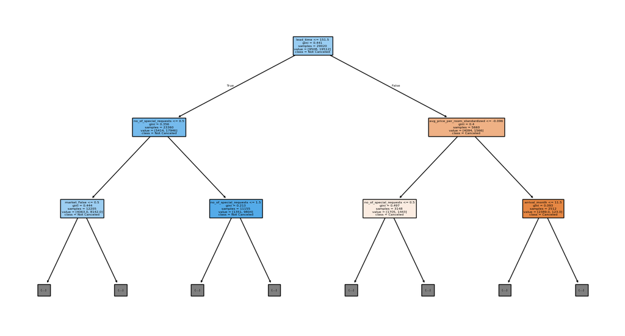

```python
from sklearn.tree import DecisionTreeClassifier, plot_tree
import matplotlib.pyplot as plt

# Build and train decision tree with early stopping (pruning)
dtree = DecisionTreeClassifier(max_depth=5, min_samples_leaf=20, random_state=42)
dtree.fit(X_train, y_train)

# Predict and evaluate
y_pred_tree = dtree.predict(X_test)
y_proba_tree = dtree.predict_proba(X_test)[:,1]

print("Decision Tree Performance:")
print(classification_report(y_test, y_pred_tree))
print("Confusion Matrix:\n", confusion_matrix(y_test, y_pred_tree))
print("ROC AUC Score:", roc_auc_score(y_test, y_proba_tree))

# Visualize the tree (optional)
plt.figure(figsize=(15,8))
plot_tree(dtree, feature_names=X.columns, class_names=['Canceled','Not Canceled'], filled=True, max_depth=2)
plt.show()
```

```python
# Important Features
tree_importance = pd.DataFrame({
    'Feature': X_train.columns,
    'Importance': dtree.feature_importances_
}).sort_values(by='Importance', ascending=False)

print(tree_importance)
```

```
                                 Feature  Importance
3                              lead_time    0.520919
10                no_of_special_requests    0.147562
29                          market_False    0.085994
27       avg_price_per_room_standardized    0.082588
28        market_segment_Offline_grouped    0.039887
11                          total_guests    0.027639
14              market_segment_Corporate    0.020964
5                          arrival_month    0.020096
0                   no_of_weekend_nights    0.017747
9                     avg_price_per_room    0.014703
1                      no_of_week_nights    0.012691
30                           market_True    0.009210
6                           arrival_date    0.000000
2             required_car_parking_space    0.000000
```

[output cut: 17 more lines]

## Model Performance Comparison and Conclusions

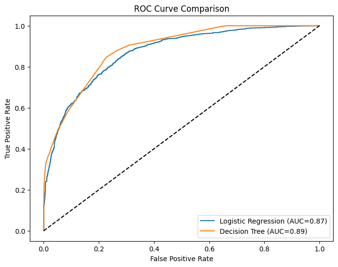

```python
import matplotlib.pyplot as plt
from sklearn.metrics import roc_curve

# ROC Curves
fpr_log, tpr_log, _ = roc_curve(y_test, y_proba_logreg)
fpr_tree, tpr_tree, _ = roc_curve(y_test, y_proba_tree)

plt.figure(figsize=(8,6))
plt.plot(fpr_log, tpr_log, label=f'Logistic Regression (AUC={roc_auc_score(y_test, y_proba_logreg):.2f})')
plt.plot(fpr_tree, tpr_tree, label=f'Decision Tree (AUC={roc_auc_score(y_test, y_proba_tree):.2f})')
plt.plot([0,1],[0,1],'k--')
plt.xlabel('False Positive Rate')
plt.ylabel('True Positive Rate')
plt.title('ROC Curve Comparison')
plt.legend()
plt.show()
```

## Actionable Insights and Recommendations

- What profitable policies for cancellations and refunds can the hotel adopt?
- What other recommedations would you suggest to the hotel?

Dynamic Cancellation Policies: Adjust policies based on predicted cancellation risk. Targeted Communication: Proactively reach out to high-risk bookings to confirm or incentivize retention. Profit Optimization: Use model predictions to inform overbooking rates and minimize revenue loss from cancellations

High Lead Time: Bookings with longer lead times are more likely to be canceled. Maybe implement stricter cancellation policies or incentives for early bookers. Special Requests: Fewer special requests may indicate less committed guests. Target these bookings with engagement emails or offers. Market Segment: Certain segments (e.g., Offline, Corporate) may have higher or lower cancellation rates. Tailor policies or communications accordingly.

```python
#Converting notebook to html
#from google.colab import files
#! jupyter nbconvert --to html '/content/drive/MyDrive/INN_hotel_data/Copy_of_Project_SLC_DSBA_INNHotels_FullCodeAWATSON_Final.ipynb'
#files.download('/content/drive/MyDrive/INN_hotel_data/Copy_of_Project_SLC_DSBA_INNHotels_FullCodeAWATSON_Final.html')
```